# Retail_Sales_Analysis

```python
# Retail Sales Performance Analysis

## Objective

### Analyse retail sales data to identify product, regional and salesperson performance and provide useful business insights.

import pandas as pd
import matplotlib.pyplot as plt

sales = pd.DataFrame({
    "Date": [
        "2025-01-05", "2025-01-12", "2025-01-20",
        "2025-02-03", "2025-02-14", "2025-02-25",
        "2025-03-04", "2025-03-15", "2025-03-28",
        "2025-04-06", "2025-04-18", "2025-04-27",
        "2025-05-08", "2025-05-19", "2025-05-29",
        "2025-06-07", "2025-06-17", "2025-06-28"
    ],

    "Region": [
        "North", "South", "East",
        "West", "North", "South",
        "East", "West", "North",
        "South", "East", "West",
        "North", "South", "East",
        "West", "North", "South"
    ],

    "Product": [
        "Laptop", "Phone", "Tablet",
        "Laptop", "Phone", "Tablet",
        "Laptop", "Phone", "Tablet",
        "Laptop", "Phone", "Tablet",
        "Laptop", "Phone", "Tablet",
        "Laptop", "Phone", "Tablet"
    ],

    "Salesperson": [
        "Alice", "Bob", "Charlie",
        "David", "Alice", "Bob",
        "Charlie", "David", "Alice",
        "Bob", "Charlie", "David",
        "Alice", "Bob", "Charlie",
        "David", "Alice", "Bob"
    ],

    "Units": [
        12, 20, 15,
        10, 25, 18,
        14, 22, 17,
        11, 28, 20,
        16, 24, 19,
        13, 30, 21
    ],

    "Revenue": [
        14400, 16000, 7500,
        12000, 20000, 9000,
        16800, 17600, 8500,
        13200, 22400, 10000,
        19200, 19200, 9500,
        15600, 24000, 10500
    ]
})

sales
```

|  | Date | Region | Product | Salesperson | Units | Revenue |
| --- | --- | --- | --- | --- | --- | --- |
| 0 | 2025-01-05 | North | Laptop | Alice | 12 | 14400 |
| 1 | 2025-01-12 | South | Phone | Bob | 20 | 16000 |
| 2 | 2025-01-20 | East | Tablet | Charlie | 15 | 7500 |
| 3 | 2025-02-03 | West | Laptop | David | 10 | 12000 |
| 4 | 2025-02-14 | North | Phone | Alice | 25 | 20000 |
| 5 | 2025-02-25 | South | Tablet | Bob | 18 | 9000 |
| 6 | 2025-03-04 | East | Laptop | Charlie | 14 | 16800 |
| 7 | 2025-03-15 | West | Phone | David | 22 | 17600 |
| 8 | 2025-03-28 | North | Tablet | Alice | 17 | 8500 |
| 9 | 2025-04-06 | South | Laptop | Bob | 11 | 13200 |
| 10 | 2025-04-18 | East | Phone | Charlie | 28 | 22400 |
| 11 | 2025-04-27 | West | Tablet | David | 20 | 10000 |
| 12 | 2025-05-08 | North | Laptop | Alice | 16 | 19200 |
| 13 | 2025-05-19 | South | Phone | Bob | 24 | 19200 |
| 14 | 2025-05-29 | East | Tablet | Charlie | 19 | 9500 |
| 15 | 2025-06-07 | West | Laptop | David | 13 | 15600 |
| 16 | 2025-06-17 | North | Phone | Alice | 30 | 24000 |
| 17 | 2025-06-28 | South | Tablet | Bob | 21 | 10500 |

```python
sales.head()
```

|  | Date | Region | Product | Salesperson | Units | Revenue |
| --- | --- | --- | --- | --- | --- | --- |
| 0 | 2025-01-05 | North | Laptop | Alice | 12 | 14400 |
| 1 | 2025-01-12 | South | Phone | Bob | 20 | 16000 |
| 2 | 2025-01-20 | East | Tablet | Charlie | 15 | 7500 |
| 3 | 2025-02-03 | West | Laptop | David | 10 | 12000 |
| 4 | 2025-02-14 | North | Phone | Alice | 25 | 20000 |

```python
sales.shape
```

```
(18, 6)
```

```python
sales.info()
```

```
<class 'pandas.DataFrame'>
RangeIndex: 18 entries, 0 to 17
Data columns (total 6 columns):
 #   Column       Non-Null Count  Dtype
---  ------       --------------  -----
 0   Date         18 non-null     str
 1   Region       18 non-null     str
 2   Product      18 non-null     str
 3   Salesperson  18 non-null     str
 4   Units        18 non-null     int64
 5   Revenue      18 non-null     int64
dtypes: int64(2), str(4)
memory usage: 996.0 bytes
```

```python
sales.describe()
```

|  | Units | Revenue |
| --- | --- | --- |
| count | 18.000000 | 18.000000 |
| mean | 18.611111 | 14744.444444 |
| std | 5.740864 | 5022.446348 |
| min | 10.000000 | 7500.000000 |
| 25% | 14.250000 | 10125.000000 |
| 50% | 18.500000 | 15000.000000 |
| 75% | 21.750000 | 18800.000000 |
| max | 30.000000 | 24000.000000 |

```python
print(sales["Revenue"].sum())
```

```
265400
```

```python
sales.groupby("Region")["Revenue"].sum().sort_values(ascending=False)
```

```
Region
North    86100
South    67900
East     56200
West     55200
Name: Revenue, dtype: int64
```

```python
Sales_by_product = (sales.groupby("Product")["Revenue"].sum()).sort_values(ascending=False)
```

```python
Sales_by_product
```

```
Product
Phone     119200
Laptop     91200
Tablet     55000
Name: Revenue, dtype: int64
```

```python
Sales_by_salesperson = (sales.groupby("Salesperson")["Revenue"].sum()).sort_values(ascending=False)
```

```python
Sales_by_salesperson
```

```
Salesperson
Alice      86100
Bob        67900
Charlie    56200
David      55200
Name: Revenue, dtype: int64
```

```python
sales.groupby("Product")["Units"].sum()
```

```
Product
Laptop     76
Phone     149
Tablet    110
Name: Units, dtype: int64
```

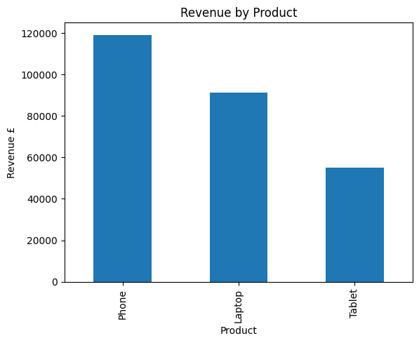

```python
## Data Visualisation and Business Insights

Sales_by_product.plot(kind="bar")

plt.title("Revenue by Product")
plt.xlabel("Product")
plt.ylabel("Revenue £")
plt.show()
```

```python
Sales_by_region = (
    sales.groupby("Region")["Revenue"]
    .sum()
    .sort_values(ascending=False)
)
```

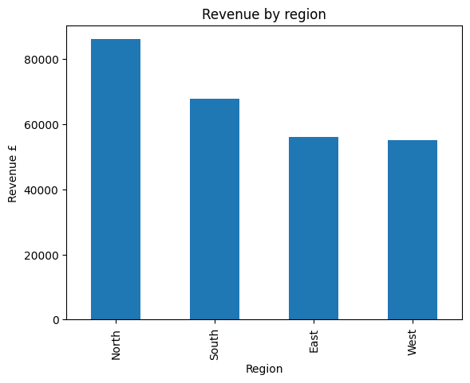

```python
Sales_by_region.plot(kind="bar")

plt.title("Revenue by region")
plt.xlabel("Region")
plt.ylabel("Revenue £")
plt.show()
```

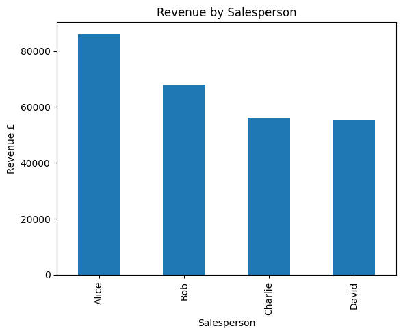

```python
Sales_by_salesperson = (sales.groupby("Salesperson")["Revenue"].sum()).sort_values(ascending=False)

Sales_by_salesperson.plot(kind="bar")

plt.title("Revenue by Salesperson")
plt.xlabel("Salesperson")
plt.ylabel("Revenue £")
plt.show()
```

```python
sales["Date"] = pd.to_datetime(sales["Date"])
```

```python
revenue_over_time = sales.groupby("Date")["Revenue"].sum()
```

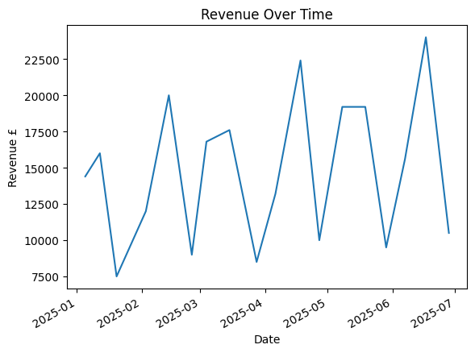

```python
revenue_over_time .plot(kind="line")

plt.title("Revenue Over Time")
plt.xlabel("Date")
plt.ylabel("Revenue £")
plt.show()
```

## Key Business Insights

1. **Product Performance:** Phones generated the highest total revenue at £119,200.
2. **Regional Performance:** The North region generated the highest total revenue at £86,100.
3. **Salesperson Performance:** Alice generated the highest total revenue at £86,100.

## Business Recommendations

1. **Prioritise Phones:** Phones generated the highest revenue and sold the most units. The company should ensure strong phone inventory levels and consider increasing marketing around this product.
2. **Investigate Regional Performance:** The North generated the highest revenue. Management should investigate what is driving its stronger performance and determine whether successful approaches can be replicated in other regions.
3. **Learn From Top Performers:** Alice generated the highest total revenue. The company could examine her sales approach and share successful practices with other salespeople.

## Conclusion

This analysis examined retail sales performance across products, regions and salespeople.

Phones were the strongest-performing product by both revenue and units sold, while the North was the highest-revenue region. Alice generated the highest revenue among salespeople.

The analysis highlights areas where the company could focus its inventory, marketing and sales strategies to improve overall performance.